# Portfolio

Name: Jingxuan Liao

Course: HUDK 4050

Semester: Fall 2021

Instructor: Lukas Liu

#### Outline:

- Part 1: Reflective Essay
- Part 2: ICEs
- Part 3: ACAs(see attachments)
- Part 4: Creative EDM assignment(see attachments)

## Reflective Essay

The entire journey of HUDK4050 Educational Data Mining is very challenging but rewarding course. It is challenging because I learn all the tools in python from scratch, and it is rewarding because I get proficient at data cleaning, data analysis, and build machine leaning models in python. The greatest asset this course has offered is a journey to self-learning.

Before this course, I had zero experience using Python to perform data cleaning and analysis, though I had learned some basic python grammar and functions. Previously, I only learned some basic statistics theories, research methods in social science, and acquired some hands-on experience in data analysis using Excel. This is not enough to find a job in data-related field. Therefore, my expectation for this course is to 1) gain some hard skills in using python for data analysis, 2) develop more mature data-driven thinking through solving real-life problem, 3) familiarize with logic and work-flow in the educational data mining through project-based learning.

The entire experience was made up of lots of ups and downs, frustrations and confidence. Indeed, as a beginner in using Python and as a neither math nor statistics major student, it is challenging for me to digest the statistics theories, not to mention applying them to programming. However, after 3 months journal, though I had not become a master, but I gain many learning methods and experience in EDM. So my biggest take-away is not about how many grammars, formulas or models I remembered, but how to approach and learn each skill-set and topic through practical and project-based exercises. Also, thanks to the sharing of industry experience from guests and professor, I gained some insights into data related workplace, which helped me to plan for my future career and make decisions on what type of job I hope to choose.

My favorite part in this course was the project-based design of assignments that encouraged self-learning and group-work which may be what we faced in real-work settings. Also, we are given the freedom to choose our own interested topics or methods of solving problems. On the other hand, the most challenging part was the theoretical parts and familiarizing with the process in Python. While doing each project, I always run into minor technical issues and had problems in interpreting and evaluating the work. The way I solved problems is through googling similar problem, asking teammates and professor for help, and watching tutorial videos on YouTube (I found several useful channels!). After a few time of project-based practices, I had become more fluent in the process from data cleaning to data analysis.

To be honest, I had thought everything to be easier and set up my standard too high. The more I dig into the data mining discipline, the more ignorant I found myself to be. However, I did feel content about the road map and guidance this course has brought to me so that I know how to navigate myself to keep learning and make progress.

In the future, work and studying, the ability to learn is critical to whether we can achieve more, and the more experience with real-world problem and interaction with others in the discipline are also my primary objectives. The action plan is to keep practice real-world projects from online database and find an internship for more practical experience.

- Word Count: 540

# ICE0: Getting Started with EDM in Python

By Jingxuan Liao

```python
import this
```

```
The Zen of Python, by Tim Peters

Beautiful is better than ugly.
Explicit is better than implicit.
Simple is better than complex.
Complex is better than complicated.
Flat is better than nested.
Sparse is better than dense.
Readability counts.
Special cases aren't special enough to break the rules.
Although practicality beats purity.
Errors should never pass silently.
Unless explicitly silenced.
In the face of ambiguity, refuse the temptation to guess.
There should be one-- and preferably only one --obvious way to do it.
Although that way may not be obvious at first unless you're Dutch.
Now is better than never.
Although never is often better than *right* now.
If the implementation is hard to explain, it's a bad idea.
If the implementation is easy to explain, it may be a good idea.
Namespaces are one honking great idea -- let's do more of those!
```

```python
print('Hello World!')
```

```
Hello World!
```

```python
x = 3
y = 7
xy = 'Whatsup'
print(x, y, x+y, xy)
```

```
3 7 10 Whatsup
```

```python
print(x)
x = 5
print(x)
x = y
print(x)
```

```
3
5
7
```

```python
a = 1 + 2
print("1 + 2 = ", a)
b = 2 - 1
print("2 - 1 = ", b)
c = 1 * 2
print("1 * 2 = ", c)
d = 9 / 3
print("9 / 3 = ", d)
```

```
1 + 2 =  3
2 - 1 =  1
1 * 2 =  2
9 / 3 =  3.0
```

```python
m = 10 % 3
print("m = ", m)
f = 10 // 3
print("f = ", f)
```

```
m =  1
f =  3
```

```python
print("a = ", a, "; m = ", m, "; f = ", f)
print("a is equal to f? ", a == f)
print("a is not equal to f?", a !=f)
print("m is smaller than f? ", m < f)
```

```
a =  3 ; m =  1 ; f =  3
a is equal to f?  True
a is not equal to f? False
m is smaller than f?  True
```

#### Working Directory

```python
import os
os.getcwd()
```

```
'/home/tarena/文档/ICE'
```

```python
# Comment won't run
```

# ICE1: Introduction to Data Manipulation in Python - PART 1

By Jingxuan Liao

```python
from emoji import emojize
# 'pip install emoji' in terminal
print(emojize(":thumbs_up:"))
```

```
👍
```

```python
import array
import numpy as np
import pandas as pd
import matplotlib.pyplot as plt
```

```python
var = "Hello World!" # string
var = 15.5 # float
var = 2 # int
var = True # boolean
var = None
```

```python
l1 = [1, 2, 3]
l2 = list(range(10)) # starts the counting from 0
l3 = [True, "2", 3.0, 4] # heterogeneous lists

print(l1)
print(l2)
print(l3)
```

```
[1, 2, 3]
[0, 1, 2, 3, 4, 5, 6, 7, 8, 9]
[True, '2', 3.0, 4]
```

```python
type(l1)
```

```
list
```

```python
A = array.array('i',l2)
A
```

```
array('i', [0, 1, 2, 3, 4, 5, 6, 7, 8, 9])
```

```python
arr1 = np.zeros(10,dtype=int)
arr2 = np.ones((3,5),dtype=float)
arr3 = np.full((3,5),3.14)
arr4 = np.random.randint(0,10,(3,3))
print('arr1:',arr1, '\narr2:', arr2, '\narr3:', arr3, '\narr4:', arr4)
```

```
arr1: [0 0 0 0 0 0 0 0 0 0]
arr2: [[1. 1. 1. 1. 1.]
 [1. 1. 1. 1. 1.]
 [1. 1. 1. 1. 1.]]
arr3: [[3.14 3.14 3.14 3.14 3.14]
 [3.14 3.14 3.14 3.14 3.14]
 [3.14 3.14 3.14 3.14 3.14]]
arr4: [[0 1 9]
 [2 2 0]
 [1 2 1]]
```

#### Pandas objects

```python
S = pd.Series([1,2,3,4.0])
S
```

```
0    1.0
1    2.0
2    3.0
3    4.0
dtype: float64
```

```python
pd.DataFrame(np.random.rand(3, 2),
             columns=['foo', 'bar'],
             index=['a', 'b', 'c'])
```

|  | foo | bar |
| --- | --- | --- |
| a | 0.588981 | 0.125963 |
| b | 0.092604 | 0.424609 |
| c | 0.444579 | 0.339036 |

#### Tidy Data

```python
ICEdata = pd.read_csv("ICE1_Data.csv")
ICEdata
```

|  | DBN | Quality_Review_Score | Progress_Rpt_10-11 | Student_Progress_10-11 | graduation 2010-11 | college enroll 2010-11 |
| --- | --- | --- | --- | --- | --- | --- |
| 0 | 01M292 | Developing | C | C | 0.563 | 0.519 |
| 1 | 01M448 | Developing | C | B | 0.707 | 0.363 |
| 2 | 01M450 | Well Developed | A | B | 0.716 | 0.692 |
| 3 | 01M509 | Proficient | C | C | 0.564 | 0.477 |
| 4 | 01M539 | Proficient | A | A | 0.953 | 0.870 |
| ... | ... | ... | ... | ... | ... | ... |
| 417 | 10X696 | Well Developed | A | A | 1.000 | 0.936 |
| 418 | 13K430 | Proficient | B | B | 0.977 | 0.867 |
| 419 | 10X445 | Well Developed | A | A | 1.000 | 0.994 |
| 420 | 14K449 | Well Developed | B | B | 0.914 | 0.961 |
| 421 | 28Q687 | Proficient | A | B | 1.000 | 0.972 |

422 rows × 6 columns

```python
import os
path = os.getcwd()
path
```

```
'/home/tarena/文档/ICE'
```

```python
ICEdata.describe(include = 'all')
```

|  | DBN | Quality_Review_Score | Progress_Rpt_10-11 | Student_Progress_10-11 | graduation 2010-11 | college enroll 2010-11 |
| --- | --- | --- | --- | --- | --- | --- |
| count | 422 | 368 | 310 | 310 | 310.000000 | 291.000000 |
| unique | 422 | 6 | 5 | 5 | NaN | NaN |
| top | 02M298 | Proficient | A | C | NaN | NaN |
| freq | 1 | 186 | 109 | 93 | NaN | NaN |
| mean | NaN | NaN | NaN | NaN | 0.737977 | 0.531196 |
| std | NaN | NaN | NaN | NaN | 0.143356 | 0.193129 |
| min | NaN | NaN | NaN | NaN | 0.412000 | 0.141000 |
| 25% | NaN | NaN | NaN | NaN | 0.625250 | 0.391000 |
| 50% | NaN | NaN | NaN | NaN | 0.726000 | 0.489000 |
| 75% | NaN | NaN | NaN | NaN | 0.850750 | 0.656000 |
| max | NaN | NaN | NaN | NaN | 1.000000 | 1.000000 |

```python
ICEdata['Quality_Review_Score'].value_counts()
```

```
Proficient                                                                                186
Well Developed                                                                            108
Developing                                                                                 64
Underdeveloped                                                                              6
Outstanding (only an option in 2007-8)                                                      3
Underdeveloped with Proficient Features (only an option in 2007-8, 2008-9 and 2009-10)      1
Name: Quality_Review_Score, dtype: int64
```

```python
qualityEnroll = graduationEnroll = ICEdata[['Quality_Review_Score', 'graduation 2010-11', 'college enroll 2010-11']]
qualityEnroll.head()
```

|  | Quality_Review_Score | graduation 2010-11 | college enroll 2010-11 |
| --- | --- | --- | --- |
| 0 | Developing | 0.563 | 0.519 |
| 1 | Developing | 0.707 | 0.363 |
| 2 | Well Developed | 0.716 | 0.692 |
| 3 | Proficient | 0.564 | 0.477 |
| 4 | Proficient | 0.953 | 0.870 |

#### Plot

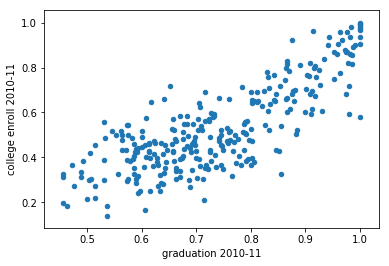

```python
graduationEnroll.plot.scatter(x = 'graduation 2010-11',
                              y = 'college enroll 2010-11')
```

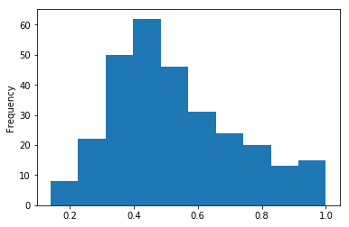

```python
graduationEnroll['college enroll 2010-11'].plot.hist()
```

## More Plots

- ‘line’ : line plot (default)
- ‘bar’ : vertical bar plot
- ‘barh’ : horizontal bar plot
- ‘hist’ : histogram
- ‘box’ : boxplot
- ‘kde’ : Kernel Density Estimation
- ‘pie’ : pie plot
- ‘scatter’ : scatter plot

#### Create and Save Array

```python
arr=np.arange(100).reshape(10,10)
np.save(file='save_arr',arr=arr)
load_data = np.load('save_arr.npy')
load_data
# We can find 'save_arr' in the current directory
```

```
array([[ 0,  1,  2,  3,  4,  5,  6,  7,  8,  9],
       [10, 11, 12, 13, 14, 15, 16, 17, 18, 19],
       [20, 21, 22, 23, 24, 25, 26, 27, 28, 29],
       [30, 31, 32, 33, 34, 35, 36, 37, 38, 39],
       [40, 41, 42, 43, 44, 45, 46, 47, 48, 49],
       [50, 51, 52, 53, 54, 55, 56, 57, 58, 59],
       [60, 61, 62, 63, 64, 65, 66, 67, 68, 69],
       [70, 71, 72, 73, 74, 75, 76, 77, 78, 79],
       [80, 81, 82, 83, 84, 85, 86, 87, 88, 89],
       [90, 91, 92, 93, 94, 95, 96, 97, 98, 99]])
```

```python
arr1=np.array([1,2,3,4])
np.savez('savez_arr',arr,arr1)
load_data2 = np.load('savez_arr.npz')
print(load_data2.files)

arr_data1 = load_data2['arr_0']
arr_data2=load_data2['arr_1']
print(arr_data1,arr_data2)
```

```
['arr_0', 'arr_1']
[[ 0  1  2  3  4  5  6  7  8  9]
 [10 11 12 13 14 15 16 17 18 19]
 [20 21 22 23 24 25 26 27 28 29]
 [30 31 32 33 34 35 36 37 38 39]
 [40 41 42 43 44 45 46 47 48 49]
 [50 51 52 53 54 55 56 57 58 59]
 [60 61 62 63 64 65 66 67 68 69]
 [70 71 72 73 74 75 76 77 78 79]
 [80 81 82 83 84 85 86 87 88 89]
 [90 91 92 93 94 95 96 97 98 99]] [1 2 3 4]
```

#### More Calculations

```python
arr=np.arange(20).reshape(4,5)
arr
```

```
array([[ 0,  1,  2,  3,  4],
       [ 5,  6,  7,  8,  9],
       [10, 11, 12, 13, 14],
       [15, 16, 17, 18, 19]])
```

```python
# Sum
print(arr.sum())
print(arr.sum(axis=1)) # row sum
print(arr.sum(axis=0)) # column sum
```

```
190
[10 35 60 85]
[30 34 38 42 46]
```

```python
# std
print(arr.std())
print(arr.std(axis=1))
print(arr.std(axis=0))
```

```
5.766281297335398
[1.41421356 1.41421356 1.41421356 1.41421356]
[5.59016994 5.59016994 5.59016994 5.59016994 5.59016994]
```

```python
# Find the maximum/minimum element
print(np.argmax(arr))
print(np.argmin(arr))
```

```
19
0
```

# ICE2: Data Manipulation Part 2

## Data Indexing

By Jingxuan Liao

### array

#### Introduction:

1. NumPy can has N dimension
2. Array is ordered list of elements

#### Difference from List in Python:

1. elements in list can be different data type, but elements in array have to be the same type
2. List cannot perform arithmetic operationn, but Array can

#### Similarity with List in Python:

1. Both can use index to locate elements

### Data manipulation in array

```python
import numpy as np

np.random.seed(123) # Setting a seed = 123 help us generate the exact same numbers

m1 = np.random.randint(0,100,size=10)
m2 = np.random.randint(10,size=(3,4)) # size = (Rows, Columns)
print("The one-dimensional array looks like this:\n",m1)
print("The two-dimensional array looks like this:\n",m2)
```

```
The one-dimensional array looks like this:
 [66 92 98 17 83 57 86 97 96 47]
The two-dimensional array looks like this:
 [[9 0 0 9]
 [3 4 0 0]
 [4 1 7 3]]
```

#### Accessing single elements

```python
print(m1[0])
print(m1[-2])
print(m2[0,-1])
```

```
66
96
9
```

#### Accessing subarrays

```python
print(m1[1:7:2])
print(m1[:5])
print(m1[5:])
print(m1[::2])
print(m2[-1])
print(m2[:2,:3]) # :2 means 1-2 rows, :3 means 1-3 columns
print(m2[:,0]) # all elements in first column
print(m2[0,:]) # all elements in first rows
print(m2[m2 > 1]) # give a condition for filtering all elements
```

```
[92 17 57]
[66 92 98 17 83]
[57 86 97 96 47]
[66 98 83 86 96]
[4 1 7 3]
[[9 0 0]
 [3 4 0]]
[9 3 4]
[9 0 0 9]
[9 9 3 4 4 7 3]
```

### Some other useful tricks for array

- np.concatenate: stacking arrays of same dimension together
- np.vstack: similar to np.concatenate, but clearer. Stack arrays together vertically.
- np.hstack: Stack arrays together horizontally.

```python
grid１ = np.array([[1, 2, 3],
                 [4, 5, 6]])
grid２ = np.array([[7, 8, 9],
                 [10,11,12]])
np.concatenate([grid1,grid2]) # don't forget the []
```

```
array([[ 1,  2,  3],
       [ 4,  5,  6],
       [ 7,  8,  9],
       [10, 11, 12]])
```

```python
np.vstack([grid1+1,grid2])
```

```
array([[ 2,  3,  4],
       [ 5,  6,  7],
       [ 7,  8,  9],
       [10, 11, 12]])
```

```python
np.hstack([grid1,grid2])
```

```
array([[ 1,  2,  3,  7,  8,  9],
       [ 4,  5,  6, 10, 11, 12]])
```

#### Other attributes

- ndim (the number of dimensions)
- shape (the size of each dimension)
- size (the total size of the array)
- reshape() an array
- np.split() an array

```python
arr1=np.array([1,2,3,4],ndmin=2)
arr1
```

```
array([[1, 2, 3, 4]])
```

```python
print(arr1.shape)
print(arr1.size)
print(arr1.reshape(1,4))
print(np.split(arr1,[2,4]))
```

```
(1, 4)
4
[[1 2 3 4]]
[array([[1, 2, 3, 4]]), array([], shape=(0, 4), dtype=int64), array([], shape=(0, 4), dtype=int64)]
```

## Data indexing in Series

```python
import pandas as pd
```

```python
s1 = pd.Series([0.25, 0.5, 0.75, 1.0],
                 index=['a', 'b', 'c', 'd'])
s1
```

```
a    0.25
b    0.50
c    0.75
d    1.00
dtype: float64
```

```python
print(s1['b']) # explicit index
print(s1[1]) # implicit index
print(s1['a':'c'])
print(s1[(s1>0.3)& (s1<0.8)])
```

```
0.5
0.5
a    0.25
b    0.50
c    0.75
dtype: float64
b    0.50
c    0.75
dtype: float64
```

```python
s2 = pd.Series(['a','b','c'],index=[1,3,5])
s2
```

```
1    a
3    b
5    c
dtype: object
```

```python
s2[1] # index 1 is stored as a number
# s2['1'] Error
```

```
'a'
```

```python
s2[1:3] # default same as iloc (implicit)
```

```
3    b
5    c
dtype: object
```

```python
s2.loc[1:3] # explicit index
```

```
1    a
3    b
dtype: object
```

```python
s2.iloc[1:3] # implicit index(from 0)
```

```
3    b
5    c
dtype: object
```

## Data indexing in DataFrame

```python
ICEdata = pd.read_csv("ICE1_Data.csv")
ICEdata
```

|  | DBN | Quality_Review_Score | Progress_Rpt_10-11 | Student_Progress_10-11 | graduation 2010-11 | college enroll 2010-11 |
| --- | --- | --- | --- | --- | --- | --- |
| 0 | 01M292 | Developing | C | C | 0.563 | 0.519 |
| 1 | 01M448 | Developing | C | B | 0.707 | 0.363 |
| 2 | 01M450 | Well Developed | A | B | 0.716 | 0.692 |
| 3 | 01M509 | Proficient | C | C | 0.564 | 0.477 |
| 4 | 01M539 | Proficient | A | A | 0.953 | 0.870 |
| ... | ... | ... | ... | ... | ... | ... |
| 417 | 10X696 | Well Developed | A | A | 1.000 | 0.936 |
| 418 | 13K430 | Proficient | B | B | 0.977 | 0.867 |
| 419 | 10X445 | Well Developed | A | A | 1.000 | 0.994 |
| 420 | 14K449 | Well Developed | B | B | 0.914 | 0.961 |
| 421 | 28Q687 | Proficient | A | B | 1.000 | 0.972 |

422 rows × 6 columns

```python
ICEdata['Quality_Review_Score']
```

```
0          Developing
1          Developing
2      Well Developed
3          Proficient
4          Proficient
            ...
417    Well Developed
418        Proficient
419    Well Developed
420    Well Developed
421        Proficient
Name: Quality_Review_Score, Length: 422, dtype: object
```

```python
ICEdata['collegeRate'] = ICEdata['college enroll 2010-11'] / ICEdata['graduation 2010-11']
ICEdata
```

|  | DBN | Quality_Review_Score | Progress_Rpt_10-11 | Student_Progress_10-11 | graduation 2010-11 | college enroll 2010-11 | collegeRate |
| --- | --- | --- | --- | --- | --- | --- | --- |
| 0 | 01M292 | Developing | C | C | 0.563 | 0.519 | 0.921847 |
| 1 | 01M448 | Developing | C | B | 0.707 | 0.363 | 0.513437 |
| 2 | 01M450 | Well Developed | A | B | 0.716 | 0.692 | 0.966480 |
| 3 | 01M509 | Proficient | C | C | 0.564 | 0.477 | 0.845745 |
| 4 | 01M539 | Proficient | A | A | 0.953 | 0.870 | 0.912907 |
| ... | ... | ... | ... | ... | ... | ... | ... |
| 417 | 10X696 | Well Developed | A | A | 1.000 | 0.936 | 0.936000 |
| 418 | 13K430 | Proficient | B | B | 0.977 | 0.867 | 0.887410 |
| 419 | 10X445 | Well Developed | A | A | 1.000 | 0.994 | 0.994000 |
| 420 | 14K449 | Well Developed | B | B | 0.914 | 0.961 | 1.051422 |
| 421 | 28Q687 | Proficient | A | B | 1.000 | 0.972 | 0.972000 |

422 rows × 7 columns

```python
ICEdata.loc[0]
```

```
DBN                           01M292
Quality_Review_Score      Developing
Progress_Rpt_10-11                 C
Student_Progress_10-11             C
graduation 2010-11             0.563
college enroll 2010-11         0.519
collegeRate                 0.921847
Name: 0, dtype: object
```

```python
ICEdata.iloc[:3, :2]
```

|  | DBN | Quality_Review_Score |
| --- | --- | --- |
| 0 | 01M292 | Developing |
| 1 | 01M448 | Developing |
| 2 | 01M450 | Well Developed |

```python
ICEdata.loc[:20, :'Progress_Rpt_10-11']
```

|  | DBN | Quality_Review_Score | Progress_Rpt_10-11 |
| --- | --- | --- | --- |
| 0 | 01M292 | Developing | C |
| 1 | 01M448 | Developing | C |
| 2 | 01M450 | Well Developed | A |
| 3 | 01M509 | Proficient | C |
| 4 | 01M539 | Proficient | A |
| 5 | 01M696 | Well Developed | B |
| 6 | 02M047 | Proficient | C |
| 7 | 02M288 | Proficient | A |
| 8 | 02M294 | Well Developed | B |
| 9 | 02M296 | Proficient | A |
| 10 | 02M298 | Well Developed | A |
| 11 | 02M300 | Proficient | B |
| 12 | 02M303 | Proficient | B |
| 13 | 02M305 | Proficient | C |
| 14 | 02M308 | Well Developed | A |
| 15 | 02M316 | Proficient | B |
| 16 | 02M374 | Proficient | C |
| 17 | 02M376 | Well Developed | NaN |
| 18 | 02M392 | Proficient | NaN |
| 19 | 02M393 | Proficient | NaN |
| 20 | 02M399 | Proficient | NaN |

```python
ICEdata[ICEdata['graduation 2010-11'] > 0.75]
```

|  | DBN | Quality_Review_Score | Progress_Rpt_10-11 | Student_Progress_10-11 | graduation 2010-11 | college enroll 2010-11 | collegeRate |
| --- | --- | --- | --- | --- | --- | --- | --- |
| 4 | 01M539 | Proficient | A | A | 0.953 | 0.870 | 0.912907 |
| 5 | 01M696 | Well Developed | B | C | 0.976 | 0.957 | 0.980533 |
| 7 | 02M288 | Proficient | A | B | 0.820 | 0.627 | 0.764634 |
| 9 | 02M296 | Proficient | A | A | 0.793 | 0.560 | 0.706179 |
| 10 | 02M298 | Well Developed | A | A | 0.915 | 0.796 | 0.869945 |
| ... | ... | ... | ... | ... | ... | ... | ... |
| 417 | 10X696 | Well Developed | A | A | 1.000 | 0.936 | 0.936000 |
| 418 | 13K430 | Proficient | B | B | 0.977 | 0.867 | 0.887410 |
| 419 | 10X445 | Well Developed | A | A | 1.000 | 0.994 | 0.994000 |
| 420 | 14K449 | Well Developed | B | B | 0.914 | 0.961 | 1.051422 |
| 421 | 28Q687 | Proficient | A | B | 1.000 | 0.972 | 0.972000 |

135 rows × 7 columns

## Data masking

```python
m2
```

```
array([[9, 0, 0, 9],
       [3, 4, 0, 0],
       [4, 1, 7, 3]])
```

```python
m2<2 # bool
```

```
array([[False,  True,  True, False],
       [False, False,  True,  True],
       [False,  True, False, False]])
```

```python
m2[m2<2]
```

```
array([0, 0, 0, 0, 1])
```

```python
mask = (m2<2) & (m2<5)
m2[mask]
```

```
array([0, 0, 0, 0, 1])
```

```python
ICEmask = (ICEdata['graduation 2010-11'] > 0.75) & (ICEdata['Progress_Rpt_10-11'] == 'A') & (ICEdata['Student_Progress_10-11'] == 'B')
ICEdata[ICEmask]
```

|  | DBN | Quality_Review_Score | Progress_Rpt_10-11 | Student_Progress_10-11 | graduation 2010-11 | college enroll 2010-11 | collegeRate |
| --- | --- | --- | --- | --- | --- | --- | --- |
| 7 | 02M288 | Proficient | A | B | 0.820 | 0.627 | 0.764634 |
| 25 | 02M412 | Proficient | A | B | 0.964 | 0.774 | 0.802905 |
| 75 | 04M435 | Well Developed | A | B | 0.920 | 0.757 | 0.822826 |
| 78 | 04M610 | Proficient | A | B | 0.984 | 0.982 | 0.997967 |
| 85 | 05M670 | Developing | A | B | 0.789 | 0.559 | 0.708492 |
| 107 | 07X548 | Proficient | A | B | 0.866 | 0.663 | 0.765589 |
| 108 | 07X551 | Proficient | A | B | 0.831 | 0.605 | 0.728039 |
| 147 | 09X543 | Well Developed | A | B | 0.765 | 0.319 | 0.416993 |
| 149 | 10X141 | Proficient | A | B | 0.870 | 0.784 | 0.901149 |
| 158 | 10X374 | Well Developed | A | B | 0.939 | NaN | NaN |
| 161 | 10X437 | Developing | A | B | 0.855 | 0.325 | 0.380117 |
| 175 | 11X275 | Proficient | A | B | 0.762 | 0.517 | 0.678478 |
| 206 | 13K419 | Proficient | A | B | 0.802 | 0.399 | 0.497506 |
| 220 | 14K478 | Well Developed | A | B | 0.847 | 0.432 | 0.510035 |
| 251 | 17K531 | Proficient | A | B | 0.787 | 0.433 | 0.550191 |
| 274 | 19K404 | Well Developed | A | B | 0.855 | 0.538 | 0.629240 |
| 305 | 22K535 | Well Developed | A | B | 0.958 | 0.862 | 0.899791 |
| 308 | 23K514 | Proficient | A | B | 0.769 | 0.467 | 0.607282 |
| 334 | 26Q430 | Proficient | A | B | 0.875 | 0.680 | 0.777143 |
| 336 | 26Q495 | Well Developed | A | B | 0.862 | 0.745 | 0.864269 |
| 356 | 28Q440 | Proficient | A | B | 0.844 | 0.649 | 0.768957 |
| 357 | 28Q505 | Proficient | A | B | 0.756 | 0.529 | 0.699735 |
| 358 | 28Q620 | Well Developed | A | B | 0.877 | 0.697 | 0.794755 |
| 383 | 31R080 | Proficient | A | B | 0.866 | 0.817 | 0.943418 |
| 384 | 31R440 | Well Developed | A | B | 0.756 | 0.473 | 0.625661 |
| 413 | 03M485 | Outstanding (only an option in 2007-8) | A | B | 0.982 | 0.861 | 0.876782 |
| 415 | 02M475 | Well Developed | A | B | 0.985 | 0.854 | 0.867005 |
| 416 | 05M692 | Well Developed | A | B | 0.982 | 0.934 | 0.951120 |
| 421 | 28Q687 | Proficient | A | B | 1.000 | 0.972 | 0.972000 |

## Combining datasets

```python
def make_df(cols,ind):
    data = {c: [str(c) + str(i) for i in ind]
            for c in cols}
    return pd.DataFrame(data, ind)
make_df('ABC',range(3))
```

|  | A | B | C |
| --- | --- | --- | --- |
| 0 | A0 | B0 | C0 |
| 1 | A1 | B1 | C1 |
| 2 | A2 | B2 | C2 |

```python
df1 = make_df('AB', [1, 2])
df2 = make_df('AB', [3, 4])
print(df1, "\n\n\n")
print(df2, "\n\n\n")
print(pd.concat([df1, df2]))
```

```
    A   B
1  A1  B1
2  A2  B2



    A   B
3  A3  B3
4  A4  B4



    A   B
1  A1  B1
2  A2  B2
3  A3  B3
4  A4  B4
```

```python
df3 = make_df('ABC', [1, 2])
df4 = make_df('BCD', [3, 4])
print(df3, "\n\n\n")
print(df4, "\n\n\n")
print(pd.concat([df3, df4]))
```

```
    A   B   C
1  A1  B1  C1
2  A2  B2  C2



    B   C   D
3  B3  C3  D3
4  B4  C4  D4



     A   B   C    D
1   A1  B1  C1  NaN
2   A2  B2  C2  NaN
3  NaN  B3  C3   D3
4  NaN  B4  C4   D4
```

```python
pd.concat([df3, df4], join = 'inner') # intersection of the columns
```

|  | B | C |
| --- | --- | --- |
| 1 | B1 | C1 |
| 2 | B2 | C2 |
| 3 | B3 | C3 |
| 4 | B4 | C4 |

```python
df5 = pd.DataFrame({'employee': ['Bob', 'Jake', 'Lisa', 'Sue'],
                    'group': ['Accounting', 'Engineering', 'Engineering', 'HR']})
df6 = pd.DataFrame({'employee': ['Lisa', 'Bob', 'Jake', 'Sue'],
                    'hire_date': [2004, 2008, 2012, 2014]})
dfm = pd.merge(df5, df6)

print(df5, "\n\n\n")
print(df6, "\n\n\n")
print(dfm)
```

```
  employee        group
0      Bob   Accounting
1     Jake  Engineering
2     Lisa  Engineering
3      Sue           HR



  employee  hire_date
0     Lisa       2004
1      Bob       2008
2     Jake       2012
3      Sue       2014



  employee        group  hire_date
0      Bob   Accounting       2008
1     Jake  Engineering       2012
2     Lisa  Engineering       2004
3      Sue           HR       2014
```

```python
df7 = pd.DataFrame({'group': ['Accounting', 'Engineering', 'HR'],
                    'supervisor': ['Carly', 'Guido', 'Steve']})

dfm = pd.merge(df5, df7)
print(df7, "\n\n\n")

print(dfm)
```

```
         group supervisor
0   Accounting      Carly
1  Engineering      Guido
2           HR      Steve



  employee        group supervisor
0      Bob   Accounting      Carly
1     Jake  Engineering      Guido
2     Lisa  Engineering      Guido
3      Sue           HR      Steve
```

```python
pd.merge(df5, df6, on='employee')
```

|  | employee | group | hire_date |
| --- | --- | --- | --- |
| 0 | Bob | Accounting | 2008 |
| 1 | Jake | Engineering | 2012 |
| 2 | Lisa | Engineering | 2004 |
| 3 | Sue | HR | 2014 |

```python
df8 = pd.DataFrame({'name': ['Bob', 'Jake', 'Lisa', 'Sue'],
                    'salary': [70000, 80000, 120000, 90000]})
print(df5)
print(df8)
```

```
  employee        group
0      Bob   Accounting
1     Jake  Engineering
2     Lisa  Engineering
3      Sue           HR
   name  salary
0   Bob   70000
1  Jake   80000
2  Lisa  120000
3   Sue   90000
```

```python
pd.merge(df5, df8, left_on = 'employee', right_on = 'name').drop('name',axis=1)
```

|  | employee | group | salary |
| --- | --- | --- | --- |
| 0 | Bob | Accounting | 70000 |
| 1 | Jake | Engineering | 80000 |
| 2 | Lisa | Engineering | 120000 |
| 3 | Sue | HR | 90000 |

## Aggregation, grouping, and pivot tables

```python
ICEdata.describe(include = 'all')
```

|  | DBN | Quality_Review_Score | Progress_Rpt_10-11 | Student_Progress_10-11 | graduation 2010-11 | college enroll 2010-11 | collegeRate |
| --- | --- | --- | --- | --- | --- | --- | --- |
| count | 422 | 368 | 310 | 310 | 310.000000 | 291.000000 | 291.000000 |
| unique | 422 | 6 | 5 | 5 | NaN | NaN | NaN |
| top | 10X438 | Proficient | A | C | NaN | NaN | NaN |
| freq | 1 | 186 | 109 | 93 | NaN | NaN | NaN |
| mean | NaN | NaN | NaN | NaN | 0.737977 | 0.531196 | 0.707836 |
| std | NaN | NaN | NaN | NaN | 0.143356 | 0.193129 | 0.168986 |
| min | NaN | NaN | NaN | NaN | 0.412000 | 0.141000 | 0.262570 |
| 25% | NaN | NaN | NaN | NaN | 0.625250 | 0.391000 | 0.589317 |
| 50% | NaN | NaN | NaN | NaN | 0.726000 | 0.489000 | 0.707569 |
| 75% | NaN | NaN | NaN | NaN | 0.850750 | 0.656000 | 0.838918 |
| max | NaN | NaN | NaN | NaN | 1.000000 | 1.000000 | 1.101227 |

```python
ICEdata.mean()
```

```
graduation 2010-11        0.737977
college enroll 2010-11    0.531196
collegeRate               0.707836
dtype: float64
```

```python
ICEdata['graduation 2010-11'].max()
```

```
1.0
```

```python
ICEdata.groupby('Quality_Review_Score')
```

```
<pandas.core.groupby.generic.DataFrameGroupBy object at 0x7f55b57fb860>
```

```python
ICEdata.groupby('Quality_Review_Score').mean()
```

| Quality_Review_Score | graduation 2010-11 | college enroll 2010-11 | collegeRate |
| --- | --- | --- | --- |
| Developing | 0.633019 | 0.402830 | 0.641309 |
| Outstanding (only an option in 2007-8) | 0.864333 | 0.747667 | 0.864183 |
| Proficient | 0.729554 | 0.521208 | 0.703604 |
| Underdeveloped | 0.549667 | 0.350167 | 0.631451 |
| Underdeveloped with Proficient Features (only an option in 2007-8, 2008-9 and 2009-10) | NaN | NaN | NaN |
| Well Developed | 0.823367 | 0.625871 | 0.752696 |

```python
ICEdata.groupby('Quality_Review_Score')['graduation 2010-11'].describe()
```

| Quality_Review_Score | count | mean | std | min | 25% | 50% | 75% | max |
| --- | --- | --- | --- | --- | --- | --- | --- | --- |
| Developing | 53.0 | 0.633019 | 0.107199 | 0.457 | 0.56300 | 0.615 | 0.69800 | 0.947 |
| Outstanding (only an option in 2007-8) | 3.0 | 0.864333 | 0.102051 | 0.800 | 0.80550 | 0.811 | 0.89650 | 0.982 |
| Proficient | 157.0 | 0.729554 | 0.135946 | 0.412 | 0.63000 | 0.722 | 0.81100 | 1.000 |
| Underdeveloped | 6.0 | 0.549667 | 0.061805 | 0.457 | 0.51525 | 0.554 | 0.59350 | 0.624 |
| Underdeveloped with Proficient Features (only an option in 2007-8, 2008-9 and 2009-10) | 0.0 | NaN | NaN | NaN | NaN | NaN | NaN | NaN |
| Well Developed | 90.0 | 0.823367 | 0.121570 | 0.545 | 0.72775 | 0.833 | 0.91875 | 1.000 |

```python
ICEdata.groupby(['Quality_Review_Score', 'Progress_Rpt_10-11']).count().unstack()
```

| Progress_Rpt_10-11 Quality_Review_Score | DBN A | DBN B | DBN C | DBN D | DBN F | Student_Progress_10-11 A | Student_Progress_10-11 B | Student_Progress_10-11 C | Student_Progress_10-11 D | Student_Progress_10-11 F | ... | college enroll 2010-11 A | college enroll 2010-11 B | college enroll 2010-11 C | college enroll 2010-11 D | college enroll 2010-11 F | collegeRate A | collegeRate B | collegeRate C | collegeRate D | collegeRate F |
| --- | --- | --- | --- | --- | --- | --- | --- | --- | --- | --- | --- | --- | --- | --- | --- | --- | --- | --- | --- | --- | --- |
| Developing | 4.0 | 11.0 | 19.0 | 16.0 | 3.0 | 4.0 | 11.0 | 19.0 | 16.0 | 3.0 | ... | 3.0 | 11.0 | 16.0 | 15.0 | 2.0 | 3.0 | 11.0 | 16.0 | 15.0 | 2.0 |
| Outstanding (only an option in 2007-8) | 3.0 | NaN | NaN | NaN | NaN | 3.0 | NaN | NaN | NaN | NaN | ... | 3.0 | NaN | NaN | NaN | NaN | 3.0 | NaN | NaN | NaN | NaN |
| Proficient | 48.0 | 65.0 | 39.0 | 5.0 | NaN | 48.0 | 65.0 | 39.0 | 5.0 | NaN | ... | 45.0 | 63.0 | 37.0 | 4.0 | NaN | 45.0 | 63.0 | 37.0 | 4.0 | NaN |
| Underdeveloped | NaN | NaN | 3.0 | 1.0 | 2.0 | NaN | NaN | 3.0 | 1.0 | 2.0 | ... | NaN | NaN | 3.0 | 1.0 | 2.0 | NaN | NaN | 3.0 | 1.0 | 2.0 |
| Well Developed | 53.0 | 26.0 | 11.0 | NaN | NaN | 53.0 | 26.0 | 11.0 | NaN | NaN | ... | 48.0 | 26.0 | 11.0 | NaN | NaN | 48.0 | 26.0 | 11.0 | NaN | NaN |

5 rows × 25 columns

```python
ICEdata.groupby('Quality_Review_Score').aggregate(['median', 'min', 'max'])
```

| Quality_Review_Score | graduation 2010-11 median | graduation 2010-11 min | graduation 2010-11 max | college enroll 2010-11 median | college enroll 2010-11 min | college enroll 2010-11 max | collegeRate median | collegeRate min | collegeRate max |
| --- | --- | --- | --- | --- | --- | --- | --- | --- | --- |
| Developing | 0.615 | 0.457 | 0.947 | 0.4030 | 0.165 | 0.658 | 0.647416 | 0.271829 | 1.048622 |
| Outstanding (only an option in 2007-8) | 0.811 | 0.800 | 0.982 | 0.6920 | 0.690 | 0.861 | 0.862500 | 0.853268 | 0.876782 |
| Proficient | 0.722 | 0.412 | 1.000 | 0.4900 | 0.183 | 0.990 | 0.699735 | 0.296503 | 1.101227 |
| Underdeveloped | 0.554 | 0.457 | 0.624 | 0.3715 | 0.141 | 0.465 | 0.712859 | 0.262570 | 0.756567 |
| Underdeveloped with Proficient Features (only an option in 2007-8, 2008-9 and 2009-10) | NaN | NaN | NaN | NaN | NaN | NaN | NaN | NaN | NaN |
| Well Developed | 0.833 | 0.545 | 1.000 | 0.5920 | 0.268 | 1.000 | 0.765269 | 0.388970 | 1.051422 |

```python
ICEdata.groupby(['Quality_Review_Score', 'Progress_Rpt_10-11'])['graduation 2010-11'].aggregate('mean').unstack()
```

| Progress_Rpt_10-11 Quality_Review_Score | A | B | C | D | F |
| --- | --- | --- | --- | --- | --- |
| Developing | 0.716500 | 0.654545 | 0.639474 | 0.613812 | 0.504333 |
| Outstanding (only an option in 2007-8) | 0.864333 | NaN | NaN | NaN | NaN |
| Proficient | 0.817083 | 0.722077 | 0.660333 | 0.526400 | NaN |
| Underdeveloped | NaN | NaN | 0.556333 | 0.457000 | 0.586000 |
| Well Developed | 0.862472 | 0.791000 | 0.711455 | NaN | NaN |

```python
ICEdata.pivot_table('graduation 2010-11', index='Quality_Review_Score', columns='Progress_Rpt_10-11')
```

| Progress_Rpt_10-11 Quality_Review_Score | A | B | C | D | F |
| --- | --- | --- | --- | --- | --- |
| Developing | 0.716500 | 0.654545 | 0.639474 | 0.613812 | 0.504333 |
| Outstanding (only an option in 2007-8) | 0.864333 | NaN | NaN | NaN | NaN |
| Proficient | 0.817083 | 0.722077 | 0.660333 | 0.526400 | NaN |
| Underdeveloped | NaN | NaN | 0.556333 | 0.457000 | 0.586000 |
| Well Developed | 0.862472 | 0.791000 | 0.711455 | NaN | NaN |

```python
ICEdata.pivot_table('graduation 2010-11',
                    index='Quality_Review_Score',
                    columns='Progress_Rpt_10-11',
                   aggfunc = 'median')
```

| Progress_Rpt_10-11 Quality_Review_Score | A | B | C | D | F |
| --- | --- | --- | --- | --- | --- |
| Developing | 0.702 | 0.6290 | 0.587 | 0.615 | 0.506 |
| Outstanding (only an option in 2007-8) | 0.811 | NaN | NaN | NaN | NaN |
| Proficient | 0.806 | 0.7150 | 0.662 | 0.531 | NaN |
| Underdeveloped | NaN | NaN | 0.537 | 0.457 | 0.586 |
| Well Developed | 0.879 | 0.8145 | 0.676 | NaN | NaN |